# Evaluación de normalidad univariada

Yuberth Anderson Saavedra Coneo

13 de junio de 2019

## Introducción

Usando el software R, se presentan algunas de las herramientas principales que se pueden utilizar para verificar la normalidad univariada en un conjunto de datos. Dichas herracmientas son:

- `plot():` gráfico de dispersión.
- `qqnorm():` gráfico cuantil - cuantil.
- `hist():` histograma de frecuencias relativas con línea de densidad.
- `cor():` coeficiente de correlación de Pearson.
- `Test de normalidad:` los test de normalidad más comunes.

Ahora bien, considere el siguiente ejemplo:

## Base de datos

La base de datos que se usará se encuentra alojada en la siguiente cuenta en [Github](https://github.com/yuasaavedraco).

```r
bd <- read.table(file = "https://raw.githubusercontent.com/yuasaavedraco/yuasaavedraco.github.io/master/Bases%20de%20datos/Acopla.txt", header = TRUE)
```

Se observan las primeras observaciones de la base de datos, así:

```r
head(bd)
```

|  | Sexo | p1 | p2 | p3 | p4 | p5 | p6 | p7 | p8 | p9 | p10 | p11 | p12 | p13 | p14 | p15 | p16 | p17 | p18 | p19 | p20 | p21 | p22 | p23 | p24 | p25 | p26 | p27 | p28 | … |
| --- | --- | --- | --- | --- | --- | --- | --- | --- | --- | --- | --- | --- | --- | --- | --- | --- | --- | --- | --- | --- | --- | --- | --- | --- | --- | --- | --- | --- | --- | --- |
| 1 | Hom | 77.4 | 32.1 | 29.9 | 27.1 | 17.2 | 20.4 | 54.2 | 50.3 | 37.1 | 37.6 | 22.5 | 26.4 | 56.6 | 120.3 | 104.5 | 103.0 | 104.2 | 99.0 | 30.1 | 32.5 | 40.1 | 37.7 | 48.2 | 51.2 | 46.7 | 58.7 | 26.3 | 21.2 | … |
| 2 | Hom | 85.5 | 33.2 | 30.7 | 27.4 | 16.5 | 20.1 | 63.2 | 58.1 | 39.0 | 37.6 | 23.5 | 25.2 | 60.3 | 119.4 | 101.0 | 92.8 | 94.8 | 103.6 | 30.3 | 35.8 | 42.7 | 38.6 | 47.8 | 45.7 | 49.7 | 62.1 | 25.7 | 20.8 | … |
| 3 | Hom | 91.6 | 37.7 | 35.6 | 30.5 | 17.5 | 21.4 | 60.2 | 57.4 | 41.6 | 41.1 | 24.0 | 26.9 | 57.3 | 124.2 | 109.8 | 104.0 | 106.2 | 104.0 | 32.4 | 34.6 | 40.9 | 38.6 | 51.7 | 55.8 | 47.3 | 59.4 | 26.5 | 21.1 | … |
| 4 | Hom | 77.0 | 30.2 | 29.8 | 28.8 | 16.8 | 20.7 | 57.2 | 53.1 | 38.6 | 39.5 | 23.8 | 24.7 | 58.6 | 116.5 | 100.6 | 87.4 | 92.6 | 98.2 | 29.7 | 32.2 | 41.1 | 36.5 | 48.7 | 46.6 | 47.6 | 59.9 | 25.0 | 20.4 | … |
| 5 | Hom | 65.8 | 32.1 | 29.2 | 26.8 | 16.4 | 21.2 | 57.1 | 53.5 | 35.5 | 36.2 | 21.0 | 25.1 | 54.1 | 115.3 | 95.6 | 82.3 | 89.0 | 94.0 | 27.4 | 31.3 | 41.2 | 36.4 | 46.6 | 43.5 | 47.1 | 57.7 | 25.3 | 20.5 | … |
| 6 | Hom | 71.1 | 30.3 | 28.8 | 26.5 | 16.4 | 20.5 | 55.6 | 52.6 | 39.2 | 37.7 | 22.3 | 25.5 | 56.0 | 114.1 | 101.4 | 89.8 | 94.2 | 97.5 | 29.3 | 33.3 | 38.6 | 37.3 | 46.1 | 44.7 | 45.8 | 55.2 | 24.4 | 19.7 | … |

Por consiguiente, se selecciona la variable `p1` para verificar si ésta distribuye normal o no.

```r
muestra <- bd[,2]   ## Vector de cuantiles muestrales
```

**Nota:** también se pueden obtener las observaciones de la variable `p1` usando **bd$p1**.

Antes de realizar el gráfico de dispersión se debe construir el vector de cuantiles muestrales y el vector de cuantiles teóricos, ésto se logra con el siguiente código en R.

```r
n <- nrow(bd)                              ## Número de observaciones de la base de datos
prob <- (1:n - 0.5) / n                    ## Proporción a la izq del i-ésimo estadístico de orden
quanti <- quantile(muestra, prob)          ## Cuantiles de la muestra correspondiente con prob. dadas
mu <- mean(muestra)                        ## Media muestral
desvi <- sd(muestra)                       ## Desviación estándar muestral
vcuan <- (quanti * desvi) + mu             ## Vector de cuantiles teóricos
mues <- sort(muestra)                      ## Vector de cuantiles muestral ordenado de menor a mayor
```

## Gráfico de dispersión

Éste gráfico permite analizar si existe algún tipo de relación entre los cuantiles muestrales versus los cuantiles teóricos de la distribución que se espera *(en este caso una normal univariada);* dicha relación se debe presentar mediante la tendencia de los puntos en linea recta con inclinación de 45°.

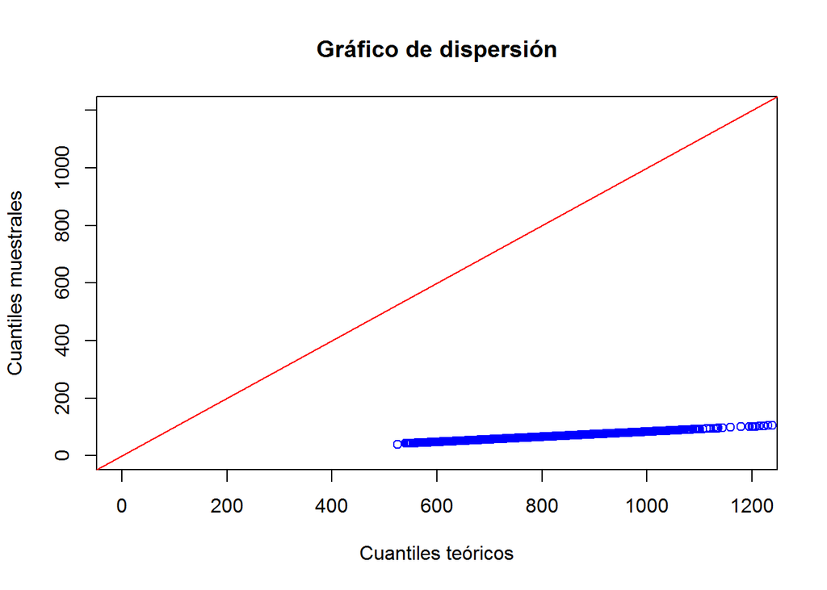

```r
plot(vcuan, mues, main = "Gráfico de dispersión", col="blue", ylim=c(0,1200), xlim=c(0,1200), ylab = "Cuantiles muestrales", xlab = "Cuantiles teóricos")

abline(0,1, col="red")      ## Linea recta de referencia con inclinación de 45°.
```

Observe que los puntos no tienen una tendencia en linea recta con inclinación de 45°; por en ende, se sospecha que la variable `p1` no tiene una distribución normal.

## Gráfico cuantil - cuantil

Este gráfico permite observar cuan cerca está la distribución de un conjunto de datos a alguna distribución ideal *(en este caso la ditribución normal univariada)* ó comparar la distribución de dos conjuntos de datos. Para obtener dicho gráfico, el paso que se debe realizar es la estandarización o normalización del conjunto de datos muestrales. El código en R es:

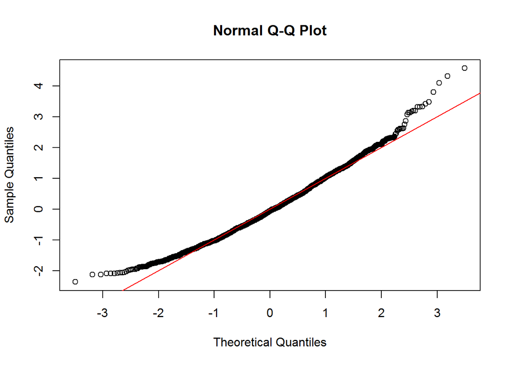

```r
muestra <- bd[, 2]                         ## Vector de cuantiles muestrales.
mu <- mean(muestra)                        ## Media muestral.
desvi <- sd(muestra)                       ## Desviación estándar muestral.
estand <- (muestra - mu) / desvi           ## Estandarización o normalización.
qqnorm(estand)                             ## Gráfico cuantil - cuantil.
abline(0,1,col="red")                      ## Linea recta de referencia con inclinación de 45°.
```

Observe que los puntos no tienen una tendencia en linea recta con inclinación de 45° ya que existen valores atípicos; esto es, un indicio de que la variable `p1` no tiene una distribución normal.

## Histograma

El histograma es una representación gráfica de una variable en forma de barras, donde la superficie de cada barra es proporcional a la frecuencia de los valores representados.

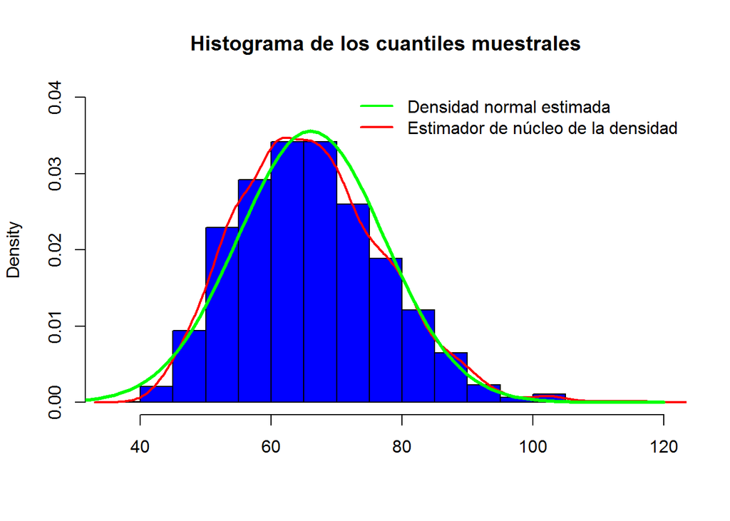

```r
hist(mues, col="blue", freq=FALSE, ylim = c(0, 0.040), main = "Histograma de los cuantiles muestrales", xlab = "")
lines(density(mues), col="red", lwd=2)
curve(dnorm(x, mean=mean(mues), sd=sd(mues)), from=0, to=120, add=TRUE, col="green", lwd=3)
legend("topright", col=c("green", "red"), legend=c("Densidad normal estimada", "Estimador de núcleo de la densidad"), lwd=2, bty = "n")
```

Se observa que la densidad del vector de cuantiles muestrales no se ajusta de la manera más adecuada a la densidad de la distribución normal estimada, a pesar de que tiene una forma acampanada, no cumple estrictamente con la simetría de una distribución normal.

## Coeficiente de correlación

Este coeficiente es un índice que puede utilizarse para medir el grado de relación lineal entre dos variables aleatorias cuantitaivas y continuas; en este caso, el interés se centra en medir dicho grado de asociación lineal entre los cuantiles muestrales y los cuantiles teóricos.

```r
cor(x = vcuan, y = mues, method = "pearson")
```

```
## [1] 0.9999739
```

Con un coeficiente de correlacion lineal igual a 0.9999739, se concluye que los cuantiles muestrales están fuertemente correlacionados con los cuantiles teóricos.

## Test de normalidad univariada

Existen muchos test para evaluar la normalidad de un conjunto de datos; sin embargo, se utilizaran los más comunes:

#### El shapiro.test()

La prueba de normalidad de Shapiro - Wilk se recomienda usar cuando se tienen muestras pequeñas, para obtenerla con el software R, use el siguiente código:

```r
a <- shapiro.test(mues)

cat("El valor-P para la prueba de Shapiro-Wilk es", a$p.value, "que prueba la NO normalidad en los datos.")
```

```
## El valor-P para la prueba de Shapiro-Wilk es 2.295127e-14 que prueba la NO normalidad en los datos.
```

#### El lillie.test()

La prueba de normalidad de Kolmogorov-Smirnov se recomienda usar cuando se tienen muestras grandes, para obtenerla con el software R se debe instalar y cargar el paquete **nortest.**

```r
# install.packages("nortest", dependencies = TRUE) ## Se instala una sola vez.
library(nortest)                                   ## Se carga cada sección.
```

```r
b <- lillie.test(mues)

cat("El valor-P para la prueba de illiefors (Kolmogorov-Smirnov) es", b$p.value, "que prueba la NO normalidad en los datos.")
```

```
## El valor-P para la prueba de illiefors (Kolmogorov-Smirnov) es 5.021723e-07 que prueba la NO normalidad en los datos.
```

#### Otras pruebas de normalidad

Enseguida se mencionan otros cuatro test usuales para probar normalidad univariada usando el software R, estos son:

- `sf.test():` prueba Shapiro-Francia.
- `ad.test():` prueba Anderson-Darling.
- `cvm.test():` prueba Cramer-von Mises.
- `pearson.test():` prueba Pearson chi-square.

## Fuente

- Iral, R., (2019). *Notas Curso Introducción al Análisis Multivariado*. Universidad Nacional de Colombia sede Medellín.
- Correa, J., y González, N. (2002). [*Gráficos Estadísticos con R*](https://cran.r-project.org/doc/contrib/grafi3.pdf), Medellín, Colombia.